# Project Phase 01: Classification and Resampling Methods

By Ahmad Hussein, Mahmoud Joumaa, & Rami Abou Fakhr

November 2023

A car company, called MAR, is working on a developing a new class of cars and has asked us, personally, for assistance. Given our strong background in machine learning, MAR has trusted us to develop various models in order to better predict the acceptability of their new product launching soon in the market. MAR has set certain features that it considers to have an impact on the likability of their product and has already collected some data from their prospective clients to study the market response towards their new car. It is now our job to study these features and understand what MAR has to invest in to maximize revenues.

# Library Imports

Before presenting our results, we have gathered all the utilized libraries in the following code block to facilitate the process of going through our report:

```r
library(corrplot)
library(leaps)
library(MASS)
library(ROCR)
library(class)
```

# Exploring the data

## Preparing the Data

As a start, we have decided to visualize the dataset graphically in order to determine what features have the highest correlational power with the car’s acceptability. To do so, we first read the data from the file `DataAssign2.csv` and stored all the rows in a variable `n`.

```r
#Load the data
data <- read.csv("DataAssign2.csv")

#Get the number of observations in the dataset
n = nrow(data)
```

Next, we proceeded to map all the qualitative outputs of every feature to quantitative values in order to facilitate the process of developing the various ML models.

```r
#Define a list which maps each categorical value into a numerical one in the database
mappings <- list(
  V1 = c("low" = 1, "med" = 2, "high" = 3, "vhigh" = 4),
  V2 = c("low" = 1, "med" = 2, "high" = 3, "vhigh" = 4),
  V3 = c("2" = 2, "3" = 3, "4" = 4, "5more" = 5),
  V4 = c("2" = 2, "4" = 4, "more" = 6),
  V5 = c("small" = 1, "med" = 2, "big" = 3),
  V6 = c("low" = 1, "med" = 2, "high" = 3),
  V7 = c("bad" = 0, "good" = 1)
)

# apply the mapping of each feature to a numerical one
data[, names(mappings)] <- lapply(names(mappings), function(col) mappings[[col]][data[[col]]])
```

## Visualizing the Data

### Correlation Matrix

After that, we used a function `cor()` to study the various correlations amongst the features with the acceptability of the car and proceeded to visualize the output of this function using `corrplot()`

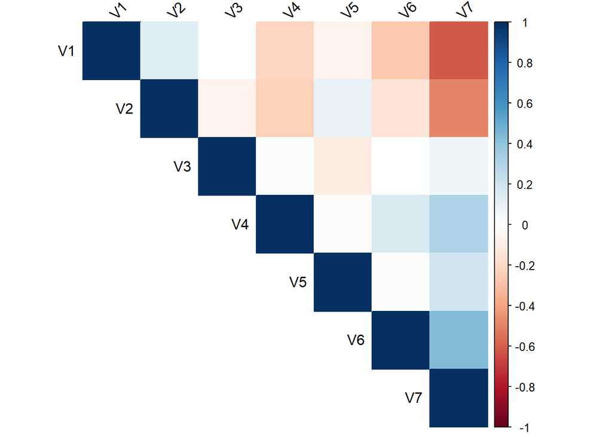

```r
# store the correlation matrix which is returned by the cor() function
correlation_matrix <- cor(data)

#use the corrplot() function from the corrplot library to plot the correlation matrix
corrplot(correlation_matrix, method = "color", type = "upper", tl.col = "black", tl.srt = 45)
```

This matrix gives a clear hint at what features actually impact the response (V7) where the red color indicates complete inverse proportionality (-1) while the blue color indicates complete direct proportionality (1). We start with each of V1 (Buying Price of the car) and V2 (Maintenance Price). In both cases, a high level of inverse proportionality between the acceptability of the car and each of its buying price and maintenance price is shown.

Finally, when crossing V7 against each of V4 (passenger capacity) and V6 (Safety), we essentially obtained the same results where the increase in each of these variables would lead to a minor increase in the acceptability of the car (light blue), proving the existence of a directly proportional relationship between V7 and each of V4 and V6. It is also possible to delve into the correlation among the features themselves, but we chose not to as the focus of this part is purely on V7.

### Response Against Each Feature Individually

We then generated a bar graph for the response against each individual feature to visualize the correlation, if it exists.

To elaborate on the source code, `par()` function was used to visualize all the bar graphs simultaneously on the screen. The red bar represents the non-acceptability of the car while green represents its acceptability.

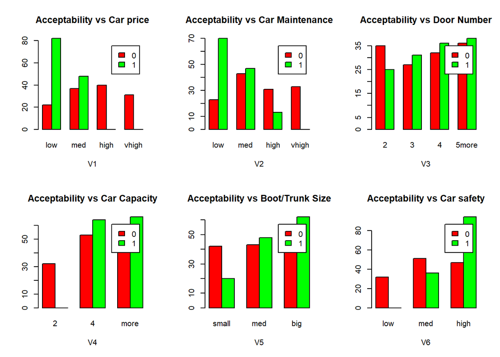

```r
# Defines the subplot grids
par(mfrow = c(2, 3))

# This function generates a barplot for the selected feature against V7
generate_barplot <- function(column, title) {
  # Creates a table which keeps count of the number of occurrence of the car acceptability (good, bad)
  counts <- table(data$V7, data[[column]])
  # Changes the column names to the actual values instead of their mappings
  colnames(counts) <- unique(names(mappings[[column]]))

  #plots the barplot
  barplot(counts, main = title,
          xlab = column, col = c("red", "green"),
          legend = rownames(counts), beside = TRUE)
}

# generates the barplot of V7 against feature V1
generate_barplot("V1", "Acceptability vs Car price")
# generates the barplot of V7 against feature V2
generate_barplot("V2", "Acceptability vs Car Maintenance")
# generates the barplot of V7 against feature V3
generate_barplot("V3", "Acceptability vs Door Number")
# generates the barplot of V7 against feature V4
generate_barplot("V4", "Acceptability vs Car Capacity")
# generates the barplot of V7 against feature V5
generate_barplot("V5", "Acceptability vs Boot/Trunk Size")
# generates the barplot of V7 against feature V6
generate_barplot("V6", "Acceptability vs Car safety")
```

```r
# Reset the subplot
par(mfrow = c(1, 1))
```

The graphs support the correlation matrix as we can clearly see how the acceptability of the car decreases when V1 and V2 increase in category and how the acceptability increases with the increase of each of V4 and V6.

# Feature Selection

Before proceeding, we decided to filter out the features that have little to no association with the acceptability of the car by following the best subset selection which is considered the optimal choice given the relatively small dataset and low number of features.

```r
# Create a formula for your logistic regression model
formula <- as.formula("V7 ~ .")

# Perform best subset selection
subset_model <- regsubsets(formula, data = data, method = "exhaustive")

# Get the summary of the subset selection
summary_subset <- summary(subset_model)

# Extract the 'which' property from the summary
subset_matrix <- summary_subset$which

subset_matrix
##   (Intercept)   V1    V2    V3    V4    V5    V6
## 1        TRUE TRUE FALSE FALSE FALSE FALSE FALSE
## 2        TRUE TRUE  TRUE FALSE FALSE FALSE FALSE
## 3        TRUE TRUE  TRUE FALSE FALSE FALSE  TRUE
## 4        TRUE TRUE  TRUE FALSE FALSE  TRUE  TRUE
## 5        TRUE TRUE  TRUE FALSE  TRUE  TRUE  TRUE
## 6        TRUE TRUE  TRUE  TRUE  TRUE  TRUE  TRUE

subset_4 <- subset_matrix[4, ]

subset_4
## (Intercept)          V1          V2          V3          V4          V5
##        TRUE        TRUE        TRUE       FALSE       FALSE        TRUE
##          V6
##        TRUE
```

The ‘which’ property of the best subset selection summary returns a matrix that informs us of the best features to include in our model for any amount of features chosen. In our case, we chose 4 features to be taken. The resulting features are the price of the car (v1), price of maintenance (v2), the size of luggage boot (v5), and estimated of the car (v6).

# Splitting The Data

In this part, we wanted to split the data into a training set and a test set using the validation set approach.

## Creating The Sets

### Setting the seed

We first set a seed to ensure reproducibility of random processes which is crucial for sharing and validating results.

```r
# set the seed
set.seed(10676)
```

### Performing The Split

Then, we proceed to shuffle the data and split our data between training and testing.

We shuffle the data to avoid any bias in our training and test sets.

```r
# shuffle the data
shuffled_data <- data[sample(n), ]

# get number of training data
num_train <- round(0.6 * n)

# get the training data from the shuffled data
train_data <- shuffled_data[1:num_train, ]

#get the test data from the shuffled data
test_data <- shuffled_data[(num_train + 1):nrow(shuffled_data), ]
```

# Developing The Model

Now, we use our training dataset to actually develop our model.

We ensure the datatype of our dataset is all numeric for proper training and then we use this numeric data to create our logistic regression model using the features of highest association with the acceptability of the car.

```r
# Change the datatype of the data to numeric
factor_cols <- names(train_data)[sapply(train_data, is.factor)]
train_data[, factor_cols] <- lapply(train_data[, factor_cols], function(x) as.numeric(as.character(x)))
test_data[, factor_cols] <- lapply(test_data[, factor_cols], function(x) as.numeric(as.character(x)))

# train the logistic regression model
model <- glm(V7~V1+V2+V5+V6, data = train_data, family = binomial)
## Warning: glm.fit: fitted probabilities numerically 0 or 1 occurred

#get a summary for the model
summary(model)
##
## Call:
## glm(formula = V7 ~ V1 + V2 + V5 + V6, family = binomial, data = train_data)
##
## Coefficients:
##             Estimate Std. Error z value Pr(>|z|)
## (Intercept)    3.225      2.771   1.164 0.244490
## V1            -6.562      1.549  -4.237 2.27e-05 ***
## V2            -6.425      1.587  -4.049 5.14e-05 ***
## V5             3.638      1.129   3.223 0.001269 **
## V6             5.133      1.457   3.523 0.000426 ***
## ---
## Signif. codes:  0 '***' 0.001 '**' 0.01 '*' 0.05 '.' 0.1 ' ' 1
##
## (Dispersion parameter for binomial family taken to be 1)
##
##     Null deviance: 214.618  on 155  degrees of freedom
## Residual deviance:  33.065  on 151  degrees of freedom
## AIC: 43.065
##
## Number of Fisher Scoring iterations: 9
```

As we can see, all predictors included appear to be statistically significant with the repsonse, especially v1, v2, and v6. This can be infered because of the significantly low p-value associated with each of these features (<0.001) which acts as an indicator for high correlation with the acceptability of the car. V5 can be considered a relatively weaker predictor due to its greater p-value.

## Confusion Matrix

Now that we have our model, we can use the function `predict()` to store the probabilities of the acceptability of the car in order to classify our responses according to a decision threshold of our choice where 0 represents the non-acceptability of the car and 1 represents its acceptability. This allows us to compute the confusion matrix.

```r
# predict the response for the testing data
predictions <- predict(model, newdata = test_data, type = "response")

# get the response from the predictions with a threshold of 0.5
predicted_classes <- ifelse(predictions > 0.5, 1, 0)

# generate the confusion matrix
conf_matrix <- table(Actual = test_data$V7, Predicted = predicted_classes)
print(conf_matrix)
##       Predicted
## Actual  0  1
##      0 43  1
##      1  2 58

# get the error
error <- 1 - (sum(diag(conf_matrix)) / sum(conf_matrix))
print(paste("Error rate=", error))
## [1] "Error rate= 0.0288461538461539"

# get the precision
precision <- conf_matrix[2, 2] / sum(conf_matrix[, 2])
print(paste("Precision=", precision))
## [1] "Precision= 0.983050847457627"

# get the recall
recall <- conf_matrix[2, 2] / sum(conf_matrix[2, ])
print(paste("Recall=", recall))
## [1] "Recall= 0.966666666666667"

# get the f1score
f1_score <- 2 * (precision * recall) / (precision + recall)
print(paste("F1_score=", f1_score))
## [1] "F1_score= 0.974789915966387"
```

Error Rate: The ratio of incorrectly classified observations = 1-accuracy. The error obtained from this matrix also represents the error rate of our logistic regression model.

TP= True Positive; the response that is correctly predicted to be positive.

FP= False Positive; the response that is falsely predicted to be positive (true nature is negative).

TN= True Negative; the response that is correctly predicted to be negative.

FN= False Negative; the response that is falsely predicted to be negative (true nature is positive).

Accuracy: The ratio of correctly classified observations = (TP+TN)/Total.

Precision: The ratio of correct positive predictions to the overall number of positive predictions = TP/(TP+FP).

Recall: The ratio of correct positive predictions to the overall number of positive observations = TP/(TP+FN).

F1 Score: The harmonic mean of precision and recall = 2*(Precision*Recall)/(Precision+Recall).

From this matrix, we can see that only 3 responses have been falsely predicted; 1 FP and 2 FN. This is reflected in our high recall and precision values indicating that our model is mostly assessing the potential acceptability of the car in the market correctly.

The precision value of 0.98 means that our model predicts an unacceptable car in the market 2% of the time. Moreover, the the recall value of 0.96 infers that our model falsely predicts the unacceptability of the car in the market 4% of the time (the true nature of the car would actually be acceptable).

# Discriminant Analysis

Similarly to logistic regression, we’re applying linear discriminant analysis (LDA) and quadratic discriminant analysis (QDA) on the provided dataset in an attempt to evaluate the performance of these different models. To compare the results, a ROC curve was constructed for each model and the corresponding AUC was computed.

## Training The Models

NOTE: Logistic Regression is reiterated over in this section for ease of navigation and comparison.

### Logistic Regression

```r
# Train the Logistic Regression model
LR_model <- glm(V7 ~ V1+V2+V5+V6, data = train_data, family = binomial)
```

### Linear Discriminant Analysis (LDA)

```r
# Train the LDA model
lda_model <- lda(V7 ~ V1+V2+V5+V6, data = train_data)
```

### Quadratic Discriminant Analysis (QDA)

```r
# Train the QDA model
qda_model <- qda(V7 ~ V1+V2+V5+V6, data = train_data)
```

## Testing the Models

After training each model, as shown in the above code snippets, the models were tested by predicting the probabilities that a certain observation would belong to the ‘non-acceptable’ class (encoded by a 0) or the ‘acceptable’ class (encoded by a 1). The chosen threshold is `0.5`. Any probability above 50% indicates that the observation belongs the acceptable class. Otherwise, the observation would belong to the non-acceptable class.

For each model, the error rate, accuracy, precision, recall, and F1 score were computed. (Refer to the definition of each in the previous section)

### Logistic Regression

```r
# predict the response for the testing data for Logistic Regression
LR_predictions <- predict(model, newdata = test_data, type = "response")

# get the response from the predictions with a threshold of 0.5
predicted_classes <- ifelse(LR_predictions > 0.5, 1, 0)

# generate the confusion matrix for Logistic Regression
conf_matrix <- table(Actual = test_data$V7, Predicted = predicted_classes)
print(conf_matrix)
```

```
##       Predicted
## Actual  0  1
##      0 43  1
##      1  2 58
```

```r
# get the error for Logistic Regression
error_rate <- 1 - (sum(diag(conf_matrix)) / sum(conf_matrix))
# get the accuracy for Logistic Regression
accuracy <- sum(diag(conf_matrix)) / sum(conf_matrix)
# get the precision for Logistic Regression
precision <- conf_matrix[2, 2] / sum(conf_matrix[, 2])
# get the recall for Logistic Regression
recall <- conf_matrix[2, 2] / sum(conf_matrix[2, ])
# get the f1score for Logistic Regression
f1_score <- 2 * (precision * recall) / (precision + recall)

error_rate
```

```
## [1] 0.02884615
```

```r
accuracy
```

```
## [1] 0.9711538
```

```r
precision
```

```
## [1] 0.9830508
```

```r
recall
```

```
## [1] 0.9666667
```

```r
f1_score
```

```
## [1] 0.9747899
```

(Refer to the previous section for the interpretation of the confusion matrix for Logsitic Regression)

### Linear Discriminant Analysis (LDA)

Similarly to that of the Logistic Regression model, the LDA’s confusion matrix shows TP, TN, FP, and FN.

```r
# predict the response for the testing data for LDA
LDA_predictions <- predict(lda_model, newdata = test_data)$posterior[, "1"]
# get the response from the predictions with a threshold of 0.5
predicted_classes <- as.numeric(LDA_predictions > 0.5)

# generate the confusion matrix for LDA
conf_matrix <- table(Actual = test_data$V7, Predicted = predicted_classes)
print(conf_matrix)
```

```
##       Predicted
## Actual  0  1
##      0 40  4
##      1  0 60
```

```r
# get the error for LDA
error_rate <- (conf_matrix[1, 2] + conf_matrix[2, 1]) / sum(conf_matrix)
# get the accuracy for LDA
accuracy <- sum(diag(conf_matrix)) / sum(conf_matrix)
# get the precision for LDA
precision <- conf_matrix[2, 2] / sum(conf_matrix[, 2])
# get the recall for LDA
recall <- conf_matrix[2, 2] / sum(conf_matrix[2, ])
# get the f1 score for LDA
f1_score <- 2 * (precision * recall) / (precision + recall)

error_rate
```

```
## [1] 0.03846154
```

```r
accuracy
```

```
## [1] 0.9615385
```

```r
precision
```

```
## [1] 0.9375
```

```r
recall
```

```
## [1] 1
```

```r
f1_score
```

```
## [1] 0.9677419
```

### Quadratic Discriminant Analysis (QDA)

Similarly to that of the Logistic Regression model and the LDA, the QDA’s confusion matrix shows TP, TN, FP, and FN.

```r
# predict the response for the testing data for QDA
QDA_predictions <- predict(lda_model, newdata = test_data)$posterior[, "1"]
# get the response from the predictions with a threshold of 0.5
predicted_classes <- as.numeric(QDA_predictions > 0.5)

# generate the confusion matrix for QDA
conf_matrix <- table(Actual = test_data$V7, Predicted = predicted_classes)
print(conf_matrix)
```

```
##       Predicted
## Actual  0  1
##      0 40  4
##      1  0 60
```

```r
# get the error for QDA
error_rate <- (conf_matrix[1, 2] + conf_matrix[2, 1]) / sum(conf_matrix)
# get the accuracy for QDA
accuracy <- sum(diag(conf_matrix)) / sum(conf_matrix)
# get the precision for QDA
precision <- conf_matrix[2, 2] / sum(conf_matrix[, 2])
# get the recall for QDA
recall <- conf_matrix[2, 2] / sum(conf_matrix[2, ])
# get the f1 score for QDA
f1_score <- 2 * (precision * recall) / (precision + recall)

error_rate
```

```
## [1] 0.03846154
```

```r
accuracy
```

```
## [1] 0.9615385
```

```r
precision
```

```
## [1] 0.9375
```

```r
recall
```

```
## [1] 1
```

```r
f1_score
```

```
## [1] 0.9677419
```

## ROC Curves

To better compare the performance of each model, a ROC curve was graphed for every model to compute each corresponding Area Under the Curve (AUC). The larger the area, the better model generally is.

```r
# create a subplot to visualize the ROC curves next to each other
par(nfrow = c(1, 3))
```

### Logistic Regression

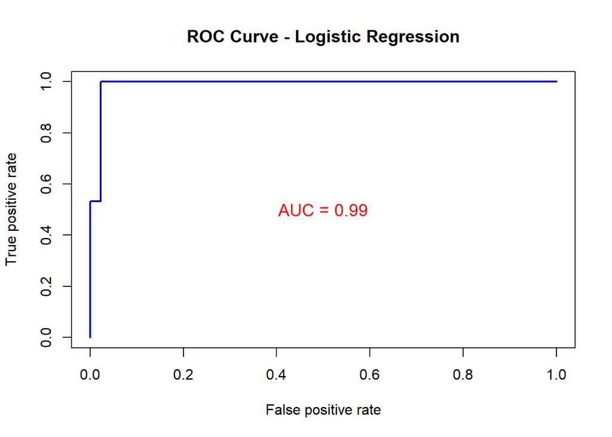

```r
# create an instance of the prediction class using LR_predictions
pred<-prediction(LR_predictions, test_data$V7)
# calculate the ROC curve values for logistic regression
perf <- performance(pred, "tpr", "fpr")
# plot the ROC curve for Logistic Regression
plot(perf, main = "ROC Curve - Logistic Regression", col = "blue", lwd = 2)
text(0.5, 0.5, paste("AUC =", round(performance(pred, "auc")@y.values[[1]], 2)), col = "red", cex = 1.2)
```

### Lineary Discriminant Analysis (LDA)

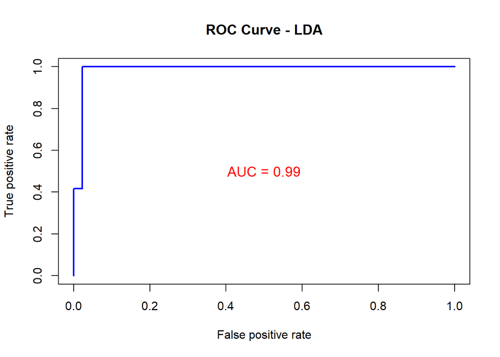

```r
# create an instance of the prediction class using lda_predictions
pred<-prediction(LDA_predictions, test_data$V7)
# calculate the ROC curve values for LDA
perf <- performance(pred, "tpr", "fpr")
# plot the ROC curve for LDA
plot(perf, main = "ROC Curve - LDA", col = "blue", lwd = 2)
text(0.5, 0.5, paste("AUC =", round(performance(pred, "auc")@y.values[[1]], 2)), col = "red", cex = 1.2)
```

### Quadratic Discriminant Analysis (QDA)

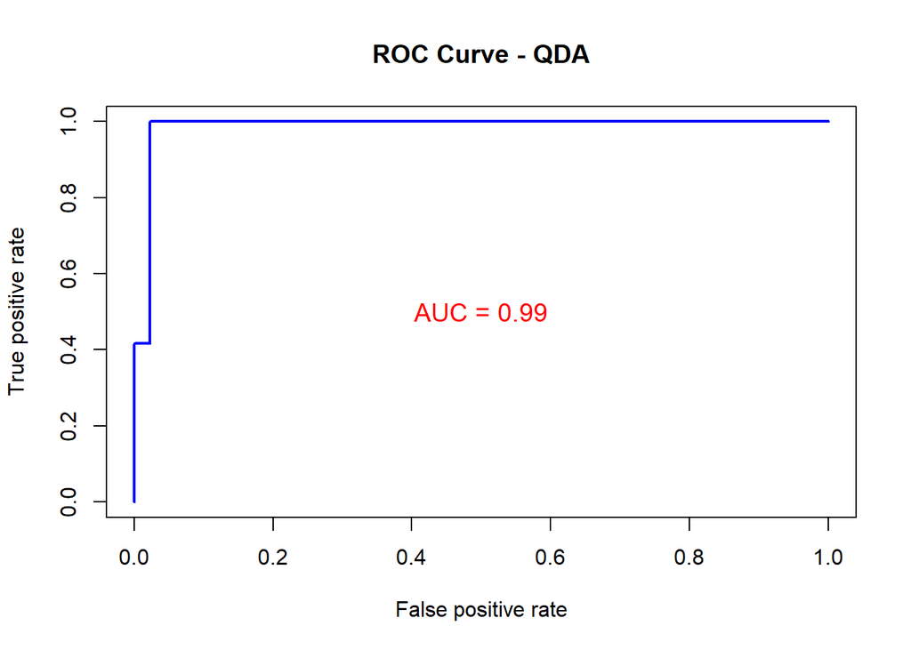

```r
# create an instance of the prediction class using qda_predictions
pred<-prediction(QDA_predictions, test_data$V7)
# calculate the ROC curve values for QDA
perf <- performance(pred, "tpr", "fpr")
# plot the ROC curve for QDA
plot(perf, main = "ROC Curve - QDA", col = "blue", lwd = 2)
text(0.5, 0.5, paste("AUC =", round(performance(pred, "auc")@y.values[[1]], 2)), col = "red", cex = 1.2)
```

# K-Nearest Neighbors (KNN)

KNN is another model that can be employed for classification problems. It executes by averaging out the k-nearest neighbors using majority rule. If the majority of the k neighbors are of a certain class, then the prediction would be as well. The different test errors obtained from different values of k were graphed in the following line graph for visualization and analysis.

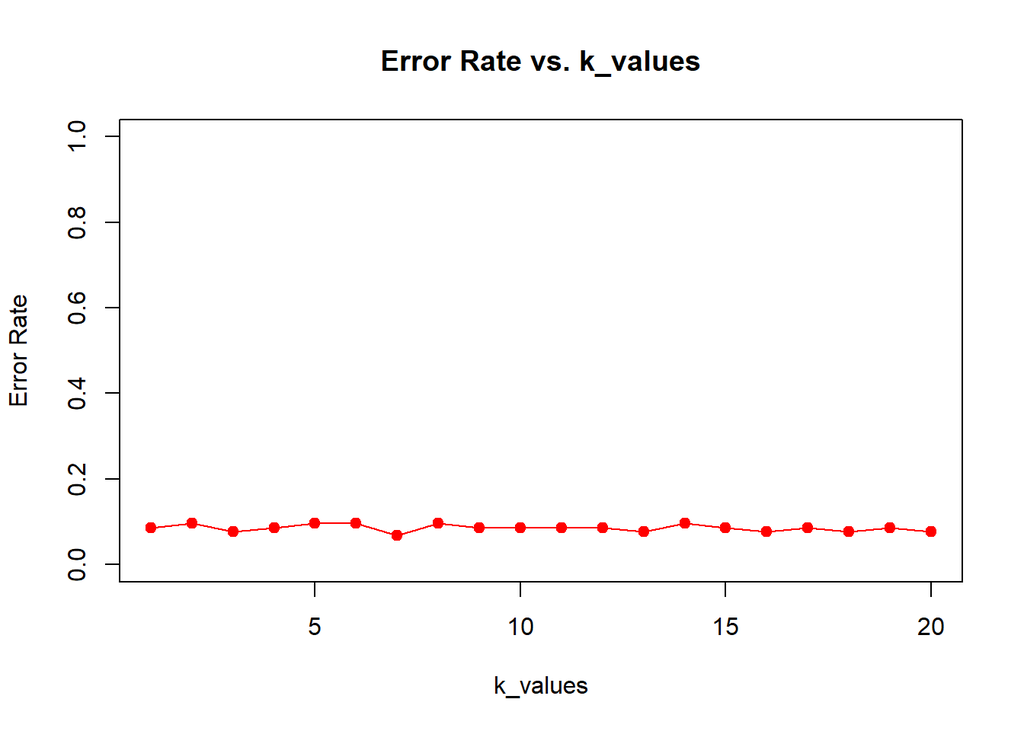

```r
# create a list of k-values to try
k_values <- seq(1, 20)

# initialize an array to keep track of the error at a particular k_value
err_y <- c()

# Run k-Nearest Neighbors for each k-value
for (k_value in k_values){
  # define the KNN model using the training data
  knn_model <- knn(train = train_data[, -which(names(train_data) == "V7")],
                   test = test_data[, -which(names(test_data) == "V7")],
                   cl = train_data$V7,
                   k = k_value)

  # Evaluate the error
  error <- sum(knn_model != test_data$V7) / length(test_data$V7)
  #append the error to the err_y list
  err_y <- append(err_y, error)
}

# plot the curve showing the error rates for each k-value used
plot(k_values, err_y, xlim = c(1, 20), ylim = c(0, 1), type = 'o',
     xlab = "k_values", ylab = "Error Rate",
     main = "Error Rate vs. k_values",
     pch = 19, col = "red")
```

The line graph shows the different errors attained for different values of k. The graph shows the test error fluctuating between a minimum at k = 7 and a maximum k = 8. Therefore, the best k for this dataset would be 7.

# Estimating the Error

To better estimate the test error of the QDA model, since the error can differ depending on the provided data, two methods are employed: Cross Validation and Bootstrap. The details of each method and their respective results are described in the following two sections.

## 5-Fold Cross-Validation

Applying a 5-fold cross-validation, our main dataset is distributed 5 different times such that the test set is 20% (i.e. one-fifth) of the original dataset size. The model trains on the remaining fourth-fifths of the dataset. This ensures that at the end of the validation, the model would have trained on all observations and tested all observations at least once. The final result displays the average of these different test errors.

```r
# define the number of test observations (20% since we are using 5-fold)
num_test <- round(0.2 * nrow(shuffled_data))
# keep track of the sum of errors for each iteration
err_sum <- 0
for (i in 1:5){
  # define the start index for the test data
  indx <- (i-1) * num_test + 1

  # define the test data
  test_data <- shuffled_data[indx:(indx+num_test-1), ]
  # define the train data
  train_data <- shuffled_data[-(indx:(indx+num_test-1)), ]
  # train the qda model
  qda_model <- qda(V7 ~ ., data = train_data)

  # get the predictions for the test data
  predictions <- predict(qda_model, newdata = test_data)$posterior[, "1"]
  # get the class of each prediction
  predicted_classes <- as.numeric(predictions > 0.5)
  # calculate the error and add it to the error sum
  err_sum <- err_sum + sum(predicted_classes != test_data$V7) / length(test_data$V7)

}

# average out the error
avg_err <- err_sum/5

avg_err
```

```
## [1] 0.02692308
```

## Bootstrap

Bootstrap is another way of better estimating the test error. It is built on the foundation of creating new datasets of the same size as the original one by randomly selecting, with replacement, different observations from the original dataset. This allows the model to train and test on “different” datasets that are generated from the same pool of observations.

```r
# define the number of training data
num_train <- round(0.6 * n)

# define the error sum
err_sum <- 0

# define the number of times to repeate the bootstrap
num_boot <- 10


for (i in 1:num_boot){
  # generate the bootstraped data
  bootstraped_data <- data[sample(n, replace = TRUE), ]
  # get the training data
  train_data <- bootstraped_data[1:num_train, ]
  # get the testing data
  test_data <- bootstraped_data[(num_train + 1):nrow(bootstraped_data), ]

  # Change the datatype of the data to numeric
  factor_cols <- names(train_data)[sapply(train_data, is.factor)]
  train_data[, factor_cols] <- lapply(train_data[, factor_cols], function(x) as.numeric(as.character(x)))
  test_data[, factor_cols] <- lapply(test_data[, factor_cols], function(x) as.numeric(as.character(x)))

  # train the qda model
  qda_model <- qda(V7 ~ V1+V2+V5+V6, data = train_data)
  # get the predictions for the test data
  predictions <- predict(qda_model, newdata = test_data)$posterior[, "1"]
  # get the class of each prediction
  predicted_classes <- as.numeric(predictions > 0.5)
  # calculate the error and add it to the error sum
  err_sum <- err_sum + sum(predicted_classes != test_data$V7) / length(test_data$V7)
}

# average out the error according to the number of bootstrap examples
avg_err = err_sum/num_boot

avg_err
```

```
## [1] 0.03173077
```

For this report, we opted to create 10 different datasets and average the test errors that resulted from each. The average error rate obtained after running bootstrap 10 times is equal to 0.031.

# Conclusion